# Chapter 5.4 Support vector machine (SVM)

A Support Vector Machine (SVM) is a supervised machine learning algorithm used for both classification and regression tasks. The core idea of an SVM is to find an optimal hyperplane that best separates data points belonging to different classes in the feature space. In the context of classification, SVMs are particularly effective for problems where data points are not linearly separable, that is, where no single straight line or plane (in higher dimensions) can cleanly divide the classes.

The support vectors in an SVM are the data points that lie closest to the decision boundary (the hyperplane) separating the classes. These points are critical because they define and determine the optimal hyperplane—directly influencing its position and orientation. SVMs are capable of handling both linear and nonlinear classification tasks. For nonlinear problems, SVMs employ a technique known as the kernel trick. A kernel function computes the inner product of two data points in a higher-dimensional feature space without explicitly transforming the data into that space. This elegant approach allows SVMs to model complex, nonlinear decision boundaries efficiently.

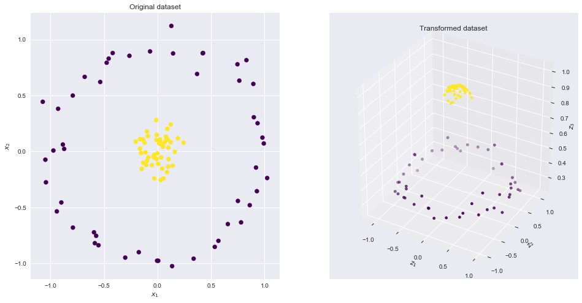

(source: https://xavierbourretsicotte.github.io/Kernel_feature_map.html)

The primary objective of an SVM is to identify this hyperplane that maximizes the margin: the distance between the hyperplane and the nearest data points from each class (the support vectors). A larger margin generally leads to better generalization, enabling the model to classify new, unseen data more accurately and robustly.

# SVM regression

Support Vector Regression (SVR), also known as Linear SVM Regression, is a machine learning technique derived from the Support Vector Machine (SVM) framework. While traditional SVMs are primarily used for classification, SVR extends the same principles to regression problems to predict continuous numerical values rather than categorical labels. The goal of SVR is to find a linear function that best approximates the relationship between input features and the target variable while maintaining a balance between model simplicity and prediction accuracy. In other words, SVR seeks a function that deviates from the observed targets by no more than a specified margin, while remaining as flat as possible.

The optimization problem for **Linear Support Vector Regression (SVR)** can be written as:

$$ \text{Minimize: } J(w, b) = \frac{1}{2} \|w\|^2 + C \sum_{i=1}^n (\xi_i + \xi_i^*) $$

subject to:

$$ y_i - (w^\top x_i + b) \leq \varepsilon + \xi_i, $$$$ (w^\top x_i + b) - y_i \leq \varepsilon + \xi_i^*, $$$$ \xi_i, \, \xi_i^* \geq 0. $$

Here:

- $w$ is the weight vector defining the slope of the regression function.
- $b$ is the bias term (intercept).
- $\|w\|^2 / 2$ is the **regularization term** that keeps the model flat.
- $\xi_i$ and $\xi_i^*$ are **slack variables** that measure deviations larger than $\varepsilon$.
- $C$ is a **regularization parameter** controlling the trade-off between model complexity and tolerance for errors.
- $\varepsilon$ defines the **insensitive margin** within which prediction errors are ignored.

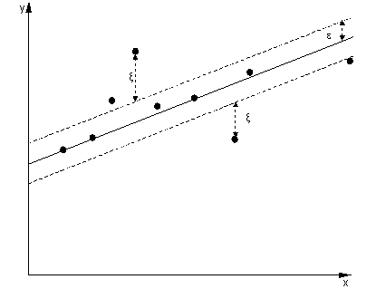

(Source: i.stack.imgur.com/5McDP.gif)

# Tuning Parameter in SVM

In **Support Vector Machines (SVMs)**, the **cost parameter** (commonly denoted as **C**) is a key **hyperparameter** that controls the trade-off between achieving a low training error and maintaining good generalization to unseen data.  
It essentially determines how strictly the SVM penalizes misclassified (or, in regression, mispredicted) data points during training.

- **When C is small:**  
  The model allows for a **wider margin** and tolerates more misclassifications or deviations from the margin.  
  This encourages a **simpler, smoother decision boundary** and helps prevent overfitting — though it may lead to **underfitting** if the margin becomes too loose.
- **When C is large:**  
  The model places **greater emphasis on correctly classifying** all training samples, even at the cost of a **smaller margin**.  
  This often yields a **more complex model** that fits the training data closely, but it may **overfit** and perform poorly on unseen data.

The parameter **C** governs the **bias–variance trade-off** in SVMs:

- A **small C** → higher bias, lower variance (simpler model).
- A **large C** → lower bias, higher variance (complex model).

Thus, tuning **C** properly is essential to balance **model flexibility** and **generalization performance**.

In practice, the optimal value of **C** is chosen through **model validation techniques** such as:

- **Cross-validation:** Evaluate model performance for several C values and select the one minimizing validation error.
- **Grid search:** Systematically explore combinations of hyperparameters (e.g., C and kernel parameters).
- **Automated optimization tools:** Functions like `tune()` in R or `GridSearchCV()` in Python streamline this process.

A well-chosen C ensures that the SVM model generalizes well and performs reliably on unseen data.

### R Packages for SVM

In **R**, several packages provide efficient implementations of SVMs:

- **`e1071`**  
  Offers functions for both **classification** and **regression** using SVMs.  
  It is based on the LIBSVM library and supports different kernels (linear, polynomial, RBF, sigmoid).  
  Example usage:

  ```
  library(e1071)
  model = svm(y ~ ., data = dat, cost = 1, kernel = "linear")
  ```

```r
library(e1071)
```

```r
library(MASS)
library(tidyverse)
library(caret)

data(Boston)
str(Boston)

set.seed(252)

index = createDataPartition(Boston$medv, p = 0.8, list = FALSE)
train.dat = Boston[index,]
test.dat =   Boston[-index,]
```

```
'data.frame':	506 obs. of  14 variables:
 $ crim   : num  0.00632 0.02731 0.02729 0.03237 0.06905 ...
 $ zn     : num  18 0 0 0 0 0 12.5 12.5 12.5 12.5 ...
 $ indus  : num  2.31 7.07 7.07 2.18 2.18 2.18 7.87 7.87 7.87 7.87 ...
 $ chas   : int  0 0 0 0 0 0 0 0 0 0 ...
 $ nox    : num  0.538 0.469 0.469 0.458 0.458 0.458 0.524 0.524 0.524 0.524 ...
 $ rm     : num  6.58 6.42 7.18 7 7.15 ...
 $ age    : num  65.2 78.9 61.1 45.8 54.2 58.7 66.6 96.1 100 85.9 ...
 $ dis    : num  4.09 4.97 4.97 6.06 6.06 ...
 $ rad    : int  1 2 2 3 3 3 5 5 5 5 ...
 $ tax    : num  296 242 242 222 222 222 311 311 311 311 ...
 $ ptratio: num  15.3 17.8 17.8 18.7 18.7 18.7 15.2 15.2 15.2 15.2 ...
 $ black  : num  397 397 393 395 397 ...
 $ lstat  : num  4.98 9.14 4.03 2.94 5.33 ...
 $ medv   : num  24 21.6 34.7 33.4 36.2 28.7 22.9 27.1 16.5 18.9 ...
```

3.90419197640732

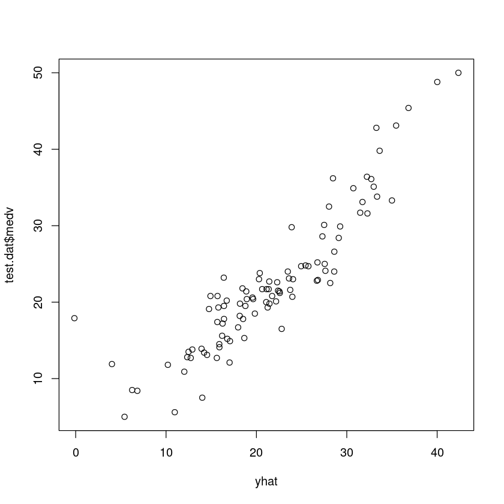

```r
#SVM regression to predict 'medv' using other variables in the dataset , using the training data

svm.fit <- svm(
  medv ~ .,
  data = train.dat,
  kernel = "linear",   # use a linear kernel for linear relationships
  cost = 5,            # regularization parameter controlling bias-variance trade-off
  scale = FALSE        # no automatic scaling of predictors
)

#Make prediction on the testing data
yhat = predict(svm.fit, test.dat)

plot(yhat, test.dat$medv)

#RMSE on the testing data of the fitted model
caret::RMSE(test.dat$medv, yhat)
```

```r
set.seed(2025)
tune.out = tune(svm, medv ~ ., data = train.dat,
                 kernel = "radial",
                 ranges = list(cost = c(0.1, 1, 5, 10),
                               gamma = c(0.01, 0.1, 0.5)))

summary(tune.out)

# Best model
best.model = tune.out$best.model

# Evaluate best model on test data
pred.best <- predict(best.model, newdata = test_scaled)
rmse.best <- sqrt(mean((pred.best - test_scaled$medv)^2))
r2.best <- cor(pred.best, test_scaled$medv)^2
```

[output not shown]

[output not shown]

#### Hyperparameter Tuning in SVM with RBF Kernel, using train function

When training a Support Vector Machine (SVM) with a **Radial Basis Function (RBF)** kernel, two key hyperparameters must be tuned to achieve the best model performance:

- **C (Cost parameter)**
- **σ (Sigma, or gamma-related parameter)**

These hyperparameters control the model’s flexibility, smoothness of the decision boundary, and tolerance for misclassification or error.

**Scaling** (also called *standardization* or *normalization*) is **strongly recommended** when using **Support Vector Machines (SVMs)**, especially with **RBF**, **polynomial**, or **sigmoid** kernels. Because SVMs are **distance-based algorithms**, features with larger numerical ranges can dominate the distance metric, leading to biased results.  
Moreover, **kernel functions** are highly sensitive to the magnitude of feature values. Without scaling, the kernel may produce distorted similarity measures, which can degrade model performance. The **optimization problem** solved by SVM (particularly when using a large cost parameter ( C ) or a small kernel width ( \sigma )) can also become **ill-conditioned** when features vary widely in scale. This can result in **slower convergence** or **suboptimal solutions** during training.

In practice, features should typically be:

- **Standardized** (mean = 0, standard deviation = 1), or
- **Normalized** (rescaled to [0, 1]).

```r
#Use train function in Caret package to select a better 'cost'
# Model training using the caret package : train function
set.seed(295)

#Cross validation
cv.control =  trainControl(method = "cv",
                           number = 5)

#
# create a tuning grid
# hyper parameter:  C and sigma
h_grid <- expand.grid(
    C = c(0.25, .5, 1, 1.5, 2.0),
    sigma = c(0.01, 0.05, 0.1, 0.15, 0.2)
)


#train to find the optimal tuning parameters
SVM.fit0 = train(medv ~ ., data = train.dat,  method = "svmRadial",
                   trControl = cv.control,
                   trace = FALSE,
                   tuneGrid = h_grid
               #    preProc = c("center", "scale"),
               #    maxit = 500
                )

# Best tuning parameters (C and sigma)
SVM.fit0$bestTune

# Cross-validation results across the grid
SVM.fit0$results

# CV profile plot (RMSE vs hyperparameters)
plot(SVM.fit0)
```

[output not shown]

A data.frame: 1 × 2

|  | sigma <dbl> | C <dbl> |
| --- | --- | --- |
| 23 | 0.1 | 2 |

2.67312196343768

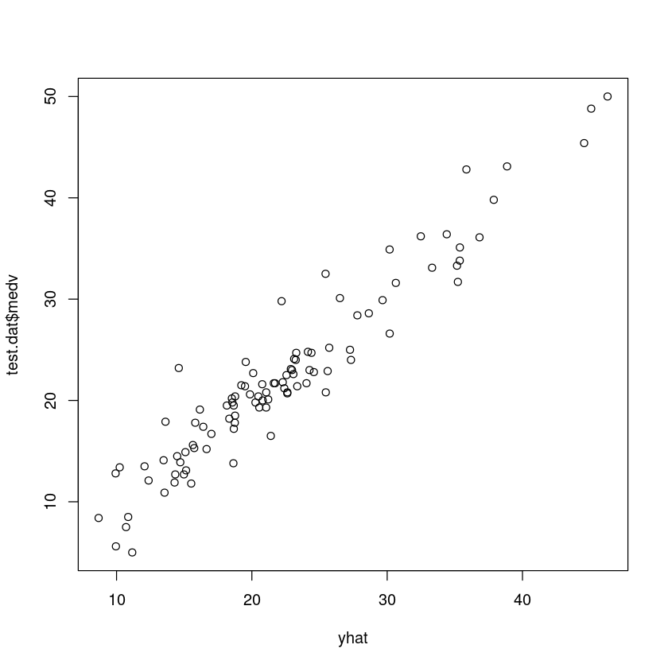

```r
#Make prediction on the testing data
yhat = predict(SVM.fit0, test.dat)

plot(yhat, test.dat$medv)

#RMSE on the testing data of the fitted model
caret::RMSE(test.dat$medv, yhat)
```

```r
#For classfication
#https://rdrr.io/cran/mlbench/man/PimaIndiansDiabetes.html
# Load the data
#data("PimaIndiansDiabetes2", package = "mlbench")
#p.data <- na.omit(PimaIndiansDiabetes2)
#svm1 <- train(diabetes ~., data = pima.data, method = "svmLinear", trControl = train_control,  preProcess = c("center","scale"))
#SVM classifier using Non-Linear Kernel
# Fit the model
#svm3 <- train(diabetes ~., data = pima.data, method = "svmRadial", trControl = train_control, preProcess = c("center","scale"), tuneLength = 10)
# Print the best tuning parameter sigma and C that maximizes model accuracy
#svm3$bestTune
#Computing SVM using polynomial basis kernel:
# Fit the model
#svm4 <- train(diabetes ~., data = pima.data, method = "svmPoly", trControl = train_control, preProcess = c("center","scale"), tuneLength = 4)
# Print the best tuning parameter sigma and C that maximizes model accuracy
#svm4$bestTune
#save the results for later
#res4<-as_tibble(svm4$results[which.min(svm4$results[,2]),])
#res4
```